# pcr replicate filtering

10 March 2022

Seems like there’s a low read depth issue for some (quite a few) PCR replicates.

I want to look at the 12S data first to determine if I should remove a subset of the PCR replicates so they don’t artifically change the mean read depths per taxon.

This notebook is the most up-to-date set of figures. It uses output from:

“01-dada2-analysis.Rmd” and “02-taxonomic-filtering.Rmd”

```r
library(dplyr)
library(tidyr)
library(stringr)
library(ggplot2)
```

## Read in ASV-sample table for Poolseq data

```r
asv_tbl <- read.csv("csv_outputs/12S_poolseq_ASVtable.csv") %>%
  rename(sample.PCR = X) %>%
  separate(sample.PCR, into = c("sample", "rep"), remove = F)
```

```
Warning: Expected 2 pieces. Additional pieces discarded in 12 rows [565, 566, 567, 568, 569, 570, 571, 572, 573, 574, 575, 576].
```

```r
# pivot longer for ease of joining
asv_long_tbl <- asv_tbl %>%
  pivot_longer(cols = 4:length(asv_tbl), names_to = "ASV", values_to = "count") %>%
  filter(count>0)
```

The warning refers to the positive and negative controls that have an extra field - not of critical concern because we still retain the control info.

I want to 1. calculate the total reads per sample 2. determine what proportion of the reads came from each replicate 3. determine whether there is a logical break between replicates with usable data and those with essentially nothing to add

How many reads per sample?

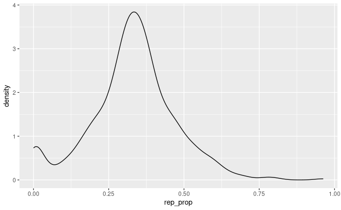

```r
asv_long_tbl %>%
  group_by(sample) %>%
  mutate(tot_reads = sum(count)) %>%
  group_by(sample.PCR) %>%
  mutate(rep_reads = sum(count)) %>%
  select(sample.PCR, sample, rep, tot_reads, rep_reads) %>%
  unique() %>% # to avoid duplicate entries
  mutate(rep_prop = rep_reads/tot_reads) %>%
  #filter(rep_prop < 0.05)
  ggplot(aes(x = rep_prop)) +
  geom_density()
```

The mean is centered right where you would expect with 3 replicates. That’s great.

Zoom in on the small blip next to zero

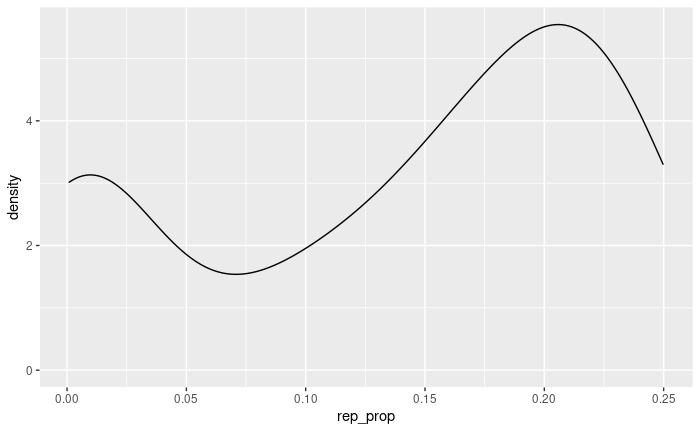

```r
asv_long_tbl %>%
  group_by(sample) %>%
  mutate(tot_reads = sum(count)) %>%
  group_by(sample.PCR) %>%
  mutate(rep_reads = sum(count)) %>%
  select(sample.PCR, sample, rep, tot_reads, rep_reads) %>%
  unique() %>% # to avoid duplicate entries
  mutate(rep_prop = rep_reads/tot_reads) %>%
  filter(rep_prop < 0.25) %>%
  ggplot(aes(x = rep_prop)) +
  geom_density()
```

To me, that looks like 0.06 is the cut-off

```r
reps.to.remove <- asv_long_tbl %>%
  group_by(sample) %>%
  mutate(tot_reads = sum(count)) %>%
  group_by(sample.PCR) %>%
  mutate(rep_reads = sum(count)) %>%
  select(sample.PCR, sample, rep, tot_reads, rep_reads) %>%
  unique() %>% # to avoid duplicate entries
  mutate(rep_prop = rep_reads/tot_reads) %>%
  filter(rep_prop < 0.06,
         !sample %in% c("POSITIVE", "NEGATIVE")) %>%
  arrange(rep)
```

30 PCR replicates are removed due to low read depth (<6% of the total reads for all three replicates for that sample).

```r
# use an anti-join to remove those replicates from the asv dataset
asv.tbl.good.reps <- asv_long_tbl %>%
  anti_join(., reps.to.remove)
```

Now try running through the 12S analysis using this dataframe

## Read in filtered taxonomy data frame

```r
# this version is filtered by Fish Atlas and contains only fishes
taxonomy <- read.csv("csv_outputs/12Sfishatlas.edna.taxonomy.csv") %>%
  select(-X, -class, -phylum, -kingdom, -common, -Sp_ScientificName) %>% # since this was already filtered by class, no reason to retain these other variables (and the common name and sci name from Fish Atlas aren't correct)
  unique() %>%
    filter(taxon != "Perciformes")
```

```r
# join data frames
uncollapsed_poolseq_tax_df <- asv.tbl.good.reps %>%
  left_join(., taxonomy, by = c("ASV" = "qseqid"))

# collapse these based on the appropriate taxonomic level
collapsed_poolseq_tax_df <- uncollapsed_poolseq_tax_df %>%
  select(sample.PCR, sample, rep, ASV, count, taxon, taxonomic_level) %>% ## I need to go back and fix the missing % for the species-level hits
  unique() %>%
  filter(!is.na(taxon),  # remove NAs
          count > 0,
         !taxon %in% c("Actinopteri", "Eukaryota"))  %>% # not informative
  select(-ASV) # remove entries with zero reads for that sequence
```

How many total unique taxa are we even worrying about?

```r
collapsed_poolseq_tax_df %>%
  select(taxon, taxonomic_level) %>%
  unique() %>%
  arrange(taxon)
```

| taxon | taxonomic_level |
| --- | --- |
| Ammodytidae | family |
| Anarrhichthys_ocellatus | species |
| Anoplopomatidae | family |
| Artedius | genus |
| Artedius_fenestralis | species |
| Atheresthes | genus |
| Aulorhynchus_flavidus | species |
| Clupeidae | family |
| Cottidae | family |
| Gadidae | family |

[output cut: 18 more lines]

```r
NA
```

Group taxonomy for ease of visualizations

```r
edna.dataframe <- collapsed_poolseq_tax_df %>%
  filter(!taxon %in% c("Sardinella", "Sardinops")) %>%
  # merge chinook into other Onchorhynchus
  mutate(taxon = ifelse(taxon == "Oncorhynchus_tshawytscha", "Oncorhynchus", taxon)) %>%
  mutate(taxon = ifelse(taxon == "Gadidae", "Gadiformes", taxon)) %>%
    mutate(taxonomic_level = ifelse(taxon == "Gadiformes", "order", taxonomic_level)) %>%
  mutate(taxon = ifelse(taxon == "Sebastes", "Sebastidae", taxon)) %>%
    mutate(taxon = ifelse(taxon == "Hexagrammos_decagrammus", "Hexagrammos", taxon)) %>%
      mutate(taxonomic_level = ifelse(taxon == "Hexagrammos", "genus", taxonomic_level)) %>%
      mutate(taxon = ifelse(taxon %in% c("Artedius_fenestralis", "Artedius", "Leptocottus_armatus"), "Cottidae", taxon)) %>%
      mutate(taxon = ifelse(taxon == "Atheresthes", "Pleuronectidae", taxon)) %>%
        mutate(taxon = ifelse(taxon == "Mallotus_villosus", "Osmeriformes", taxon)) %>%
          mutate(taxon = ifelse(taxon == "Aulorhynchus_flavidus", "Gasterosteoidei", taxon)) %>%
            mutate(taxon = ifelse(taxon == "Trichodon_trichodon", "Trichodontidae", taxon)) %>%
              mutate(taxon = ifelse(taxon == "Lipolagus_ochotensis", "Bathylagidae", taxon)) %>%
                mutate(taxon = ifelse(taxon == "Anarrhichthys_ocellatus", "Anarhichadidae", taxon)) %>%
  select(-taxonomic_level) %>%
  # the taxonomic levels aren't accurate, so let's remove those... probably not important from here on out.
  group_by(sample.PCR, taxon) %>%
  mutate(count = sum(count)) %>% # sum reads across taxa
  unique()
```

```r
# save that
edna.dataframe %>%
  write.csv("csv_outputs/12S_filteredGoodPCRreplicatesData.csv")
```

## Add metadata to that data frame

```r
# metadata tidied and ready to go
meta <- read.csv("../metadata/amalga_clean_metadata.csv") %>%
  # fix the 100m samples, which are actually between the pens and the creek
  mutate(distance = ifelse(distance == 100, -100, distance)) %>%
  mutate(dist_grp = distance)

meta
```

| sample | location | label | type | tide | dist_grp | distance |
| --- | --- | --- | --- | --- | --- | --- |
| e00019 | PM | 1120m | eDNA | outgoing | 1120 | 1120 |
| e00020 | PM | 1120m | eDNA | outgoing | 1120 | 1120 |
| e00021 | PM | 1120m | eDNA | outgoing | 1120 | 1120 |
| e00022 | PM | 1200m | eDNA | outgoing | 1200 | 1200 |
| e00023 | PM | 1200m | eDNA | outgoing | 1200 | 1200 |
| e00024 | PM | 1200m | eDNA | outgoing | 1200 | 1200 |
| e00025 | PM | 1280m | eDNA | outgoing | 1280 | 1280 |
| e00026 | PM | 1280m | eDNA | outgoing | 1280 | 1280 |
| e00027 | PM | 1280m | eDNA | outgoing | 1280 | 1280 |
| e00028 | PM | 1360m | eDNA | outgoing | 1360 | 1360 |

[output cut: 162 more lines]

```r
filtered_df_w_metadata <- edna.dataframe %>%
  left_join(., meta) %>%
  filter(!is.na(location))
```

```r
# need to group taxa within the same sample/distance and remove duplicates before plotting
mean.reads.df.to.plot <- filtered_df_w_metadata %>%
  group_by(taxon, tide, distance) %>%
  mutate(mean_reads = mean(count)) %>% # this is the mean number of reads per taxon/tide/distance
  select(taxon, tide, distance, mean_reads) %>% # need to pare down to just this set of variables to avoid counting multiple times
  unique()
```

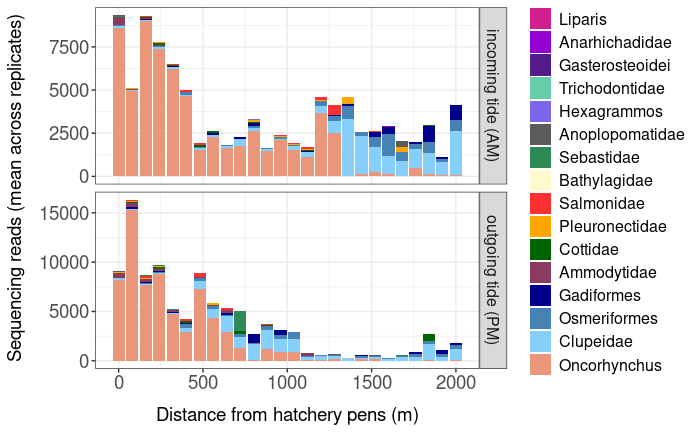

```r
# mean reads per taxon/tide/distance
mean.reads.df.to.plot %>%
  filter(!is.na(tide),
         distance > -10) %>%
  mutate(tide = ifelse(tide == "incoming", "incoming tide (AM)", "outgoing tide (PM)")) %>%
  ggplot(aes(x = distance, y = mean_reads, fill = reorder(taxon, mean_reads))) +
  geom_bar(stat="identity") +
  facet_grid(rows = vars(tide), scales = "free_y") +
  theme_bw() +
   theme(
    axis.text.x = element_text(size = 14),
    axis.text.y = element_text(size = 14),
    axis.title.x = element_text(margin = margin(t=10), size = 14),
    axis.title.y = element_text(margin = margin(r=10), size = 14),
    legend.text = element_text(size = 12),
    legend.title = element_blank(),
    strip.text = element_text(size = 12)
    ) +
  labs(
    y = "Sequencing reads (mean across replicates)",
    x = "Distance from hatchery pens (m)",
    fill = "Taxon") +
  scale_fill_manual(values = c('violetred', "darkviolet", 'purple4','aquamarine3', 'slateblue2', "gray36",'seagreen4', "lemonchiffon", 'firebrick1', "orange1", 'darkgreen', 'hotpink4',"darkblue",'steelblue','lightskyblue', 'darksalmon'))

ggsave("pdf_outputs/12SmeanReadsDistanceGoodReplicates.pdf", width = 9, height = 5)
```

## Make taxon proportions plot

```r
prop.df <- filtered_df_w_metadata %>%
  filter(!is.na(tide),
         type == "eDNA") %>% # remove the controls with no metadata
  select(-location, -label, -dist_grp) %>%
  group_by(distance, tide, taxon) %>% # group by distance
  mutate(tot_tax_reads = sum(count)) %>%
  group_by(distance, tide, taxon) %>%
  mutate(taxon_count = sum(count)) %>%
  select(distance, taxon, tide, tot_tax_reads) %>%
  unique() %>% # if we don't call unique here, it duplicates the summed entries
  group_by(distance, tide) %>%
  mutate(taxon_prop = tot_tax_reads/sum(tot_tax_reads))
```

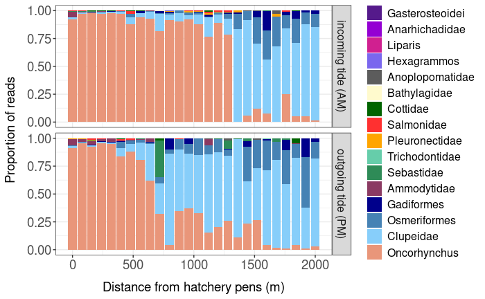

```r
# plot relative proportions of taxa within a tide/distance group
# plot used for PPT
prop.df %>%
    filter(distance > -10) %>%
  mutate(tide = ifelse(tide == "incoming", "incoming tide (AM)", "outgoing tide (PM)")) %>%
  ggplot(aes(distance, taxon_prop, fill = reorder(taxon, taxon_prop)))+
  geom_bar(stat="identity", position="stack") +
  facet_grid(rows = vars(tide)) +
  theme_bw() +
 theme(
    axis.text.x = element_text(size = 14),
    axis.text.y = element_text(size = 14),
    axis.title.x = element_text(margin = margin(t=10), size = 14),
    axis.title.y = element_text(margin = margin(r=10), size = 14),
    legend.text = element_text(size = 12),
    legend.title = element_blank(),
    strip.text = element_text(size = 12)
    ) +
  labs(y = "Proportion of reads",
       x = "Distance from hatchery pens (m)",
       fill = "Taxon") +
  scale_fill_manual(values = c( 'purple4',"darkviolet", 'violetred', 'slateblue2', "gray36", "lemonchiffon",  'darkgreen', 'firebrick1', "orange1",  'aquamarine3',  'seagreen4', 'hotpink4', "darkblue", 'steelblue','lightskyblue', 'darksalmon'))
# the colors match the other two plots, even though the taxon order has changed.

ggsave("pdf_outputs/12SproportionsDistanceGoodReplicates.pdf", width = 9, height = 5)
```

## What does the “background” look like if we subtract out the chum signal?

Sequencing reads

```r
background.plot.reads <- mean.reads.df.to.plot %>%
  filter(!is.na(tide),
         taxon != "Oncorhynchus",
         distance > -10) %>%
  mutate(tide = ifelse(tide == "incoming", "incoming tide (AM)", "outgoing tide (PM)")) %>%
  ggplot(aes(x = distance, y = mean_reads, fill = reorder(taxon, mean_reads))) +
  geom_bar(stat="identity") +
  facet_grid(rows = vars(tide), scales = "free_y") +
  theme_bw() +
   theme(
    axis.text.x = element_text(size = 14),
    axis.text.y = element_text(size = 14),
    axis.title.x = element_text(margin = margin(t=10), size = 14),
    axis.title.y = element_text(margin = margin(r=10), size = 14),
    legend.text = element_text(size = 12),
    legend.title = element_blank(),
    strip.text = element_text(size = 12)
    ) +
  labs(
    y = "Sequencing reads (mean across replicates)",
    x = "Distance from hatchery pens (m)",
    fill = "Taxon") +
  scale_fill_manual(values = c('violetred', "darkviolet", 'purple4','aquamarine3', 'slateblue2', "gray36",'seagreen4', "lemonchiffon", 'firebrick1', "orange1", 'darkgreen', 'hotpink4',"darkblue",'steelblue','lightskyblue', 'darksalmon'))
```

Proportions

```r
# for proportions, I need to remove the Oncorhynchus reads before calculating the prop of reads per taxon

prop.minus.salmon <- filtered_df_w_metadata %>%
  filter(!is.na(tide),
         taxon != "Oncorhynchus",
         type == "eDNA") %>% # remove the controls with no metadata
  select(-location, -label, -dist_grp) %>%
  group_by(distance, tide, taxon) %>% # group by distance
  mutate(tot_tax_reads = sum(count)) %>%
  group_by(distance, tide, taxon) %>%
  mutate(taxon_count = sum(count)) %>%
  select(distance, taxon, tide, tot_tax_reads) %>%
  unique() %>% # if we don't call unique here, it duplicates the summed entries
  group_by(distance, tide) %>%
  mutate(taxon_prop = tot_tax_reads/sum(tot_tax_reads))

# plot

background.plot.prop <- prop.minus.salmon %>%
    filter(distance > -10) %>%
  mutate(tide = ifelse(tide == "incoming", "incoming tide (AM)", "outgoing tide (PM)")) %>%
  ggplot(aes(distance, taxon_prop, fill = reorder(taxon, taxon_prop)))+
  geom_bar(stat="identity", position="stack") +
  facet_grid(rows = vars(tide)) +
  theme_bw() +
 theme(
    axis.text.x = element_text(size = 14),
    axis.text.y = element_text(size = 14),
    axis.title.x = element_text(margin = margin(t=10), size = 14),
    axis.title.y = element_text(margin = margin(r=10), size = 14),
    legend.text = element_text(size = 12),
    legend.title = element_blank(),
    strip.text = element_text(size = 12)
    ) +
  labs(y = "Proportion of reads",
       x = "Distance from hatchery pens (m)",
       fill = "Taxon") +
  scale_fill_manual(values = c('violetred',"darkviolet",'purple4', "gray36",'slateblue2',  'aquamarine3',  "lemonchiffon", 'darkgreen', 'seagreen4',"orange1", 'firebrick1', "darkblue", 'steelblue', 'hotpink4', 'lightskyblue', 'darksalmon'))
# the colors match the other two plots, even though the taxon order has changed.

ggsave(background.plot.prop, file = "pdf_outputs/Amalga12SproportionsNoOncorhynchus.pdf", width = 9, height = 5)
```

[figure not shown]

## Adding a linear model for the Oncorhynchus reads to compare to qPCR and Cyt b data

Get the counts for chum salmon across the transect and figure out how reads counts compare to the qPCR results.

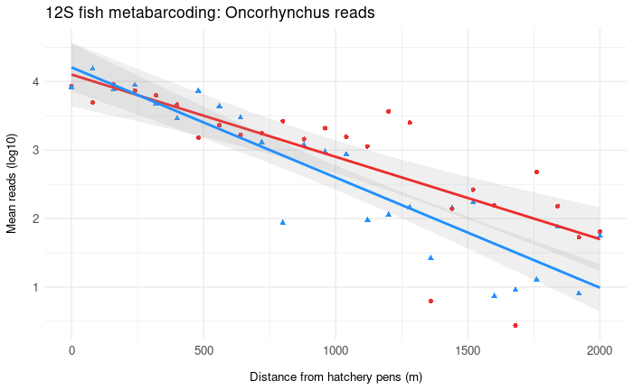

```r
linearModel.12S.plot <- mean.reads.df.to.plot %>%
  filter(taxon == "Oncorhynchus",
         distance>-10) %>%
    mutate(tide = ifelse(tide == "incoming", "Incoming tide (AM)", "Outgoing tide (PM)")) %>% # rename labels for plot
    ggplot(aes(x = distance, y = log10(mean_reads), color = tide, shape = tide)) +
    geom_point() +
    geom_smooth(method = "lm", alpha = 0.15) +
    #facet_grid(rows = vars(tide), scales = "free_y") +
    theme_minimal() +
    theme(
    axis.title.x = element_text(margin = margin(t=12), size = 10),
    #axis.title.x = element_blank(),
    axis.title.y = element_text(margin = margin(r=12), size = 10),
    axis.text = element_text(size = 10),
    legend.title = element_blank(),
    #legend.title = element_text(size = 14),
    legend.text = element_text(size = 10),
    #legend.position = c(0.8, 0.85)
    legend.position = "none"
  ) +
    labs(
      y = "Mean reads (log10)",
         x = "Distance from hatchery pens (m)",
      title = "12S fish metabarcoding: Oncorhynchus reads") +
  scale_color_manual(values = c("firebrick2", "dodgerblue"))

linearModel.12S.plot

ggsave("pdf_outputs/12SLog10linearModelOncorhynchus_long.pdf", width = 6, height = 2)
```

Linear model using log10

```r
# create a new variable with the log10 mean reads
lm.df <- mean.reads.df.to.plot %>%
  filter(taxon == "Oncorhynchus",
         distance>-10) %>%
  mutate(log_reads = log10(mean_reads))

# incoming tide
incoming_df <- lm.df %>%
  filter(tide == "incoming")

# outgoing tide
outgoing_df <- lm.df %>%
  filter(tide == "outgoing")

# linear model
incoming_model<-lm(log_reads~distance,data=incoming_df)

summary(incoming_model)$r.squared
```

```
[1] 0.6168866
```

```r
outgoing_model <- lm(log_reads~distance, data=outgoing_df)

summary(outgoing_model)$r.squared
```

```
[1] 0.8377266
```

R^2 incoming = 0.62 outgoing = 0.84

I bet the fit is even better until 1000 m.

```r
# chop off the dataframe after 1000 m
# incoming tide
incoming_df <- lm.df %>%
  filter(tide == "incoming",
         distance <1000)

# outgoing tide
outgoing_df <- lm.df %>%
  filter(tide == "outgoing",
         distance<1000)

# linear model
incoming_model<-lm(log_reads~distance,data=incoming_df)

summary(incoming_model)$r.squared
```

```
[1] 0.7007142
```

```r
outgoing_model <- lm(log_reads~distance, data=outgoing_df)

summary(outgoing_model)$r.squared
```

```
[1] 0.6155775
```

## Revisiting the PCR replicate filter

31 January 2023

Does lower read depth in a given replicate change the species composition of that replicate?